# Lecture 2: Summarizing and cleaning data

CPECGM2

## Agenda

- Dataframe basics
- Data cleaning tasks
- Data aggregation

## Preliminaries

#### Installing and loading packages

- packages: open source extensions to R. Contain new functions.
- Let’s download the package `plyr` for todays lecture. Use the `Tools -> Install Packages...` dropdown menu option to do this.
  - We did this last lecture to download `rmarkdown`
- After downloading a package, you need to tell R to load it into memory. The command for this is `library`:

```r
library(plyr)
```

- If you use a package, you need to load it into memory each time you start R. (but you only need to download it once)
  - Reason: packages can be made by anyone, so they may contain different functions that are identically named.
- The following commands in today’s lecture are from the `plyr` package: `ddply()`, `mutate()`, `arrange()`, `summarize()`, and `revalue()`.
- The author of a package will often write a short PDF tutorial explaining its use. In the R community these are called “vignettes”, and you can often find them using google. The vignette for `plyr` is here: http://www.jstatsoft.org/v40/i01/paper

#### Setting the working diretory

- To set the working directory, use the `Session -> Set working directory ...` dropdown menu option.
- Often you’ll want to set the directory to the location of the source file.

#### Reading a data file in comma-separated-value (CSV) format.

- The data file `expenditures_lec2.csv` contains demographic information and spending patterns of 45 households in the US.
- To load this file as a data frame, type:

```r
# Load the file and save it as a data frame called expenditures.
# Don't forget to change the working directory if necessary!
expenditures = read.table(file='expenditures_lec2.csv', header=T, sep=',')
```

| Argument | Description |
| --- | --- |
| `file` | Name of the file |
| `header` | `header=T` means the first row of the file contains the column names |
| `sep` | `sep=','` means the data entries are separated by commas |

- Could also use `read.csv(file='expenditures.csv', header=T)`, which assumes that `sep=','`.

#### Viewing a data frame

```r
# what are the dimensions of the data frame?
dim(expenditures)  # expenditures has 45 rows and 10 columns
```

```
## [1] 45 10
```

```r
# look at the first few rows of a data frame
head(expenditures)
```

```
##   household.id    region  population.size income.class family.size
## 1      2227674   Midwest       4 million+ $20K-$29,999           1
## 2      2227914 Northeast       4 million+        $70K+           3
## 3      2228025     South 125-329 thousand $50K-$69,999           4
## 4      2228115 Northeast       4 million+        $70K+           4
## 5      2228274      West 125-329 thousand $15K-$19,999           3
## 6      2228385      West       4 million+   $5K-$9,999           2
##   age.respondent food housing healthcare transportation
## 1             81  715 1170.00      700.2              0
## 2             41 2856 6457.00     2253.0           1761
## 3             36 1365 2165.00      750.0           1736
## 4             45 3200 5343.00      690.0           3026
## 5             50  715 2752.00      798.4            568
## 6             68 1148  396.75        0.0              0
```

```r
# print a summary of the data frame
summary(expenditures)
```

```
##   household.id        region          population.size    income.class
##  Min.   :2227674   Length:45          Length:45          Length:45
##  1st Qu.:2229094   Class :character   Class :character   Class :character
##  Median :2230825   Mode  :character   Mode  :character   Mode  :character
##  Mean   :2230789
##  3rd Qu.:2232365
##  Max.   :2234045
##   family.size    age.respondent       food         housing
##  Min.   :1.000   Min.   :22.00   Min.   : 364   Min.   :  396.8
##  1st Qu.:1.000   1st Qu.:36.00   1st Qu.:1031   1st Qu.: 2340.0
##  Median :2.000   Median :47.00   Median :1433   Median : 2945.0
##  Mean   :2.578   Mean   :51.09   Mean   :1751   Mean   : 3734.8
##  3rd Qu.:4.000   3rd Qu.:68.00   3rd Qu.:2525   3rd Qu.: 4456.0
##  Max.   :7.000   Max.   :87.00   Max.   :4420   Max.   :15363.0
##    healthcare     transportation
##  Min.   :   0.0   Min.   :    0
##  1st Qu.:  90.0   1st Qu.:  378
##  Median : 678.4   Median :  902
##  Mean   : 770.7   Mean   : 1476
##  3rd Qu.:1096.0   3rd Qu.: 1378
##  Max.   :5056.4   Max.   :20632
```

- For a spreadsheet-style view of the data frame, in Rstudio you can type `View(expenditures)` into the console, or click on the variable in environment window.

## A tiny bit of data cleaning

#### Changing the column names in a data frame

```r
# what are the names of the columns?
names(expenditures)
```

```
##  [1] "household.id"    "region"          "population.size" "income.class"
##  [5] "family.size"     "age.respondent"  "food"            "housing"
##  [9] "healthcare"      "transportation"
```

```r
# change the 3th column name from population.size to pop.size
names(expenditures)[3] = 'pop.size'
names(expenditures)
```

```
##  [1] "household.id"   "region"         "pop.size"       "income.class"
##  [5] "family.size"    "age.respondent" "food"           "housing"
##  [9] "healthcare"     "transportation"
```

```r
# change the 1st and 3rd columns to id.number and population.size
names(expenditures)[ c(1,3) ] = c('id.number', 'population.size')
```

#### Missing data values

- Look at the last row of `expenditures`

```r
expenditures[45, ]
```

```
##    id.number region population.size income.class family.size age.respondent
## 45   2234045   <NA>            <NA> $40K-$49,999           1             41
##    food housing healthcare transportation
## 45 1105    2691        904           1006
```

- `NA` stands for missing values
- Missing values can cause R to behave in unexpected ways
- Example: can’t take the mean when there are missing values

```r
# create a vector with missing values
vec = c(25, 73, NA, 22)
# R returns NA for the mean if there are missing values
mean(vec)
```

```
## [1] NA
```

```r
# optional argument: remove missing values before taking mean
mean(vec, na.rm=T)
```

```
## [1] 40
```

- Different functions may behave in different ways or have arguments to change the default behavior. This can cause unexpected behavior!
- Better to check beforehand if there are missing values in your data.
- `complete.cases()` returns a boolean vector for each row indicating if there are no NA values:

```r
# Only the last row has missing data
complete.cases(expenditures)
```

```
##  [1]  TRUE  TRUE  TRUE  TRUE  TRUE  TRUE  TRUE  TRUE  TRUE  TRUE  TRUE  TRUE
## [13]  TRUE  TRUE  TRUE  TRUE  TRUE  TRUE  TRUE  TRUE  TRUE  TRUE  TRUE  TRUE
## [25]  TRUE  TRUE  TRUE  TRUE  TRUE  TRUE  TRUE  TRUE  TRUE  TRUE  TRUE  TRUE
## [37]  TRUE  TRUE  TRUE  TRUE  TRUE  TRUE  TRUE  TRUE FALSE
```

```r
# let's look at this row
expenditures[ !complete.cases(expenditures), ]
```

```
##    id.number region population.size income.class family.size age.respondent
## 45   2234045   <NA>            <NA> $40K-$49,999           1             41
##    food housing healthcare transportation
## 45 1105    2691        904           1006
```

- The `is.na()` command gives a boolean check whether a value is NA:

```r
is.na( expenditures$population.size)
```

```
##  [1] FALSE FALSE FALSE FALSE FALSE FALSE FALSE FALSE FALSE FALSE FALSE FALSE
## [13] FALSE FALSE FALSE FALSE FALSE FALSE FALSE FALSE FALSE FALSE FALSE FALSE
## [25] FALSE FALSE FALSE FALSE FALSE FALSE FALSE FALSE FALSE FALSE FALSE FALSE
## [37] FALSE FALSE FALSE FALSE FALSE FALSE FALSE FALSE  TRUE
```

- You can use the `subset()` command with the logical function `is.na()` to check for NAs is a particular column:

```r
# keep all rows where income.class is not NA:
expenditures = subset(expenditures, subset = !is.na(population.size))
expenditures
```

```
##    id.number    region        population.size income.class family.size
## 1    2227674   Midwest             4 million+ $20K-$29,999           1
## 2    2227914 Northeast             4 million+        $70K+           3
## 3    2228025     South       125-329 thousand $50K-$69,999           4
## 4    2228115 Northeast             4 million+        $70K+           4
## 5    2228274      West       125-329 thousand $15K-$19,999           3
## 6    2228385      West             4 million+   $5K-$9,999           2
## 7    2228494   Midwest       125-329 thousand $15K-$19,999           1
## 8    2228735     South       125-329 thousand $40K-$49,999           2
## 9    2228775 Northeast             4 million+ $50K-$69,999           1
## 10   2228915 Northeast             4 million+ $20K-$29,999           3
## 11   2229075 Northeast             4 million+ $30K-$39,999           5
## 12   2229094     South             4 million+   $5K-$9,999           1
## 13   2229365   Midwest less than 125 thousand $40K-$49,999           2
## 14   2229544   Midwest             4 million+ $50K-$69,999           5
```

[output cut: 75 more lines]

```r
# Q: how about
# expenditures = subset(expenditures, subset = complete.cases(expenditures)) ?
```

#### Coded Data

```r
# the first 8 elements of expenditures$region:
expenditures$region[1:8]
```

```
## [1] "Midwest"   "Northeast" "South"     "Northeast" "West"      "West"
## [7] "Midwest"   "South"
```

The `levels` command gives you a text vector of the factor levels:

```r
levels(expenditures$region)
```

[output not shown]

#### Relabeling coded data

- Use the `mapvalues()` command (part of `plyr` package)
- Let’s change the label `Northeast` to the more descriptive label `Cold`:

```r
# change Northeast to Cold
expenditures$region = mapvalues(expenditures$region, from="Northeast", to="Cold")
expenditures$region[1:8]
```

```
## [1] "Midwest" "Cold"    "South"   "Cold"    "West"    "West"    "Midwest"
## [8] "South"
```

```r
# change multiple labels at once
expenditures$region = mapvalues(expenditures$region,
                                from=c('Midwest', 'Cold', 'South', 'West'),
                                to=c('MW', 'NE', 'S', 'W'))
expenditures$region[1:8]
```

```
## [1] "MW" "NE" "S"  "NE" "W"  "W"  "MW" "S"
```

```r
# save typing with the levels command:
#expenditures$region = mapvalues(expenditures$region,
#                                from = levels(expenditures$region),
 #                               to = c('Midwest', 'Northeast', 'South', 'West'))
#expenditures$region[1:8]
```

- Typing `?mapvalues` shows that it requires 3 arguments
  - `x`: the vector
  - `from`: a text vector with the old descriptive labels of factor levels
  - `to`: a text vector with the new descriptive labels for the factor levels in `from`
- `mapvalues` is useful for reducing the number of different factor levels:

```r
# what does this do?
expenditures$income.class = mapvalues(expenditures$income.class,
                          from = c("$5K-$9,999", "$10K-$14,999", "$15K-$19,999",
                            "$20K-$29,999", "$30K-$39,999", "$40K-$49,999",
                            "$50K-$69,999", "$70K+"),
                          to = c("low", "low", "low", "medium", "medium", "medium", "high", "high") )
expenditures$income.class
```

```
##  [1] "medium" "high"   "high"   "high"   "low"    "low"    "low"    "medium"
##  [9] "high"   "medium" "medium" "low"    "medium" "high"   "high"   "low"
## [17] "high"   "high"   "high"   "high"   "low"    "medium" "medium" "high"
## [25] "high"   "medium" "high"   "medium" "high"   "high"   "high"   "low"
## [33] "high"   "high"   "high"   "high"   "medium" "low"    "high"   "high"
## [41] "medium" "high"   "medium" "medium"
```

#### Converting factors to numbers

R will silently convert your categorical data from text into factors and vice versa, depending on the application.

Usually this is what you want. Sometimes, R will get confused and give you unexpected output. Then you can tell R explicitly what the type of the variable should be. You can use the following commands:

- `as.factor(x)`: converts `x` into a factor
- `as.numeric(x)`: converts `x` into a number if possible, or returns `NA` if `x` is non-numeric.
- `as.character(x)`: converts `x` into a text vector

It will be easier to motivate these commands later in the course as need arises. The less you have to worry about this, the better. But here are some examples:

```r
x = c('Bill', 'Betty', 'Bob')
# convert to a factor, with listed levels
as.factor(x)
```

```
## [1] Bill  Betty Bob
## Levels: Betty Bill Bob
```

```r
# convert to a number? R returns NA
as.numeric(x)
```

```
## [1] NA NA NA
```

```r
# convert to a factor and save as x:
x = as.factor(x)
# we can see x is a factor since the levels are listed
x
```

```
## [1] Bill  Betty Bob
## Levels: Betty Bill Bob
```

```r
# factors are internally numbers, so we can convert to numeric now if we want
as.numeric(x)
```

```
## [1] 2 1 3
```

```r
# we can convert back to character if we want
as.character(x)
```

```
## [1] "Bill"  "Betty" "Bob"
```

```r
# what will this do?
as.numeric(as.character( x) )
```

```
## [1] NA NA NA
```

```r
# occaisionally you get text numbers
x = c("5", "24", "15", "fifty-four")
# we can convert this mostly to numbers
as.numeric(x)
```

```
## [1]  5 24 15 NA
```

```r
# suppose R converts this to a factor...
x = as.factor(x)
x
```

```
## [1] 5          24         15         fifty-four
## Levels: 15 24 5 fifty-four
```

```r
# now the levels are internally numbers, returned by as.numeric:
as.numeric(x)
```

```
## [1] 3 2 1 4
```

```r
# if we want to get back 5, 24, and 15, we have to convert to character first!
as.numeric( as.character(x))
```

```
## [1]  5 24 15 NA
```

#### The `with()` command

- Repeatedly referencing a column in a data frame (like `expenditures$region`) is verbose.
- In the `with()` command, you specify the data frame once and then its columns can be referenced by name
- The `with()` command can make your code more readable (and thus less error-prone).

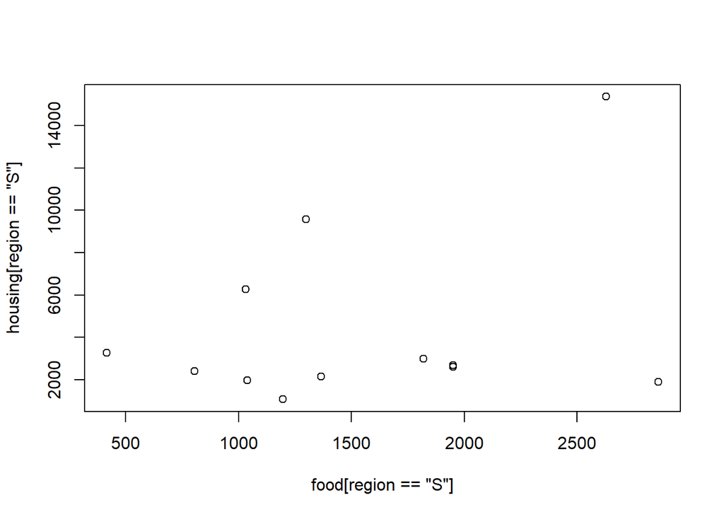

```r
# make a plot
with(expenditures, plot(x=food[ region == "S" ], y=housing[ region == "S"])) # easier to read!
```

## Data aggregation

#### Finding aggregate statistics with `summarize()`

- The command `summarize()` can be used to summarize a data frame:

```r
summarize(expenditures, avg.food = mean(food), avg.housing = mean(housing), n.households = length(housing))
```

```
##   avg.food avg.housing n.households
## 1  1765.25    3758.551           44
```

#### Grouping and then finding aggregate statistics

- `ddply()` breaks up a data frame into smaller groups, and then calls a function of your choosing on each group:

```r
# group by region and then take summary
ddply(expenditures, "region", summarize, avg.food = mean(food), avg.housing = mean(housing), n.households = length(housing))
```

```
##   region  avg.food avg.housing n.households
## 1     MW 1847.2500    3874.516           16
## 2     NE 2080.3077    3355.558           13
## 3      S 1530.2500    4360.250           12
## 4      W  902.6667    2479.583            3
```

```r
# group by region and income class
counts = ddply(expenditures, c("region", "income.class"), summarize, n.households = length(housing))
counts
```

```
##    region income.class n.households
## 1      MW         high            8
## 2      MW          low            2
## 3      MW       medium            6
## 4      NE         high            7
## 5      NE          low            2
## 6      NE       medium            4
## 7       S         high            7
## 8       S          low            2
## 9       S       medium            3
## 10      W         high            1
## 11      W          low            2
```

#### Adding new columns that are statistics

The `mutate()` command is similar to `summarize()`, except that it keeps the original data frame.

```r
# What is the total spent by each household?
expenditures = mutate(expenditures, total = food + housing + healthcare + transportation)
head(expenditures)
```

```
##   id.number region  population.size income.class family.size age.respondent
## 1   2227674     MW       4 million+       medium           1             81
## 2   2227914     NE       4 million+         high           3             41
## 3   2228025      S 125-329 thousand         high           4             36
## 4   2228115     NE       4 million+         high           4             45
## 5   2228274      W 125-329 thousand          low           3             50
## 6   2228385      W       4 million+          low           2             68
##   food housing healthcare transportation    total
## 1  715 1170.00      700.2              0  2585.20
## 2 2856 6457.00     2253.0           1761 13327.00
## 3 1365 2165.00      750.0           1736  6016.00
## 4 3200 5343.00      690.0           3026 12259.00
## 5  715 2752.00      798.4            568  4833.40
## 6 1148  396.75        0.0              0  1544.75
```

- `mutate()` can also be combined with `ddply()`. A common task is to convert counts into percentages:

```r
# What fraction of households in each region are in each income class?
ddply(counts, "region", mutate, percent = n.households / sum(n.households))
```

```
##    region income.class n.households   percent
## 1      MW         high            8 0.5000000
## 2      MW          low            2 0.1250000
## 3      MW       medium            6 0.3750000
## 4      NE         high            7 0.5384615
## 5      NE          low            2 0.1538462
## 6      NE       medium            4 0.3076923
## 7       S         high            7 0.5833333
## 8       S          low            2 0.1666667
## 9       S       medium            3 0.2500000
## 10      W         high            1 0.3333333
## 11      W          low            2 0.6666667
```

- The `transform()` command is very similar to `mutate()` command

#### Grouping by continuous variables with `cut()`

- `cut()` creates discrete labels from continuous data

```r
# create age categories manually
expenditures$age.cat = cut(expenditures$age.respondent, breaks = c(0, 30, 50, 70, Inf), labels = c('0-30', '31-50', '51-70', '71+'))
# use the age categories to group the data and find average family size
ddply(expenditures, "age.cat", summarize, avg.fam.size = mean(family.size))
```

```
##   age.cat avg.fam.size
## 1    0-30     3.200000
## 2   31-50     3.238095
## 3   51-70     2.200000
## 4     71+     1.125000
```

- `cut_number()` (part of the `ggplot2` package) assign labels so that each group has the same number of elements, which can sometimes be helpful.

```r
library(ggplot2)
expenditures$age.cat = cut_number(expenditures$age.respondent, n = 4, labels = c('A', 'B', 'C', 'D'))
# how many members in each category? Should be equal:
ddply(expenditures, "age.cat", summarize, size = length(age.cat))
```

```
##   age.cat size
## 1       A   11
## 2       B   11
## 3       C   11
## 4       D   11
```

## R coding style

(taken from 94-842)

- Objective: make your code easy to read
- A few R “style guides” exist:
  - [Google’s](https://google-styleguide.googlecode.com/svn/trunk/Rguide.xml) (a bit long)
  - [Hadley Wickham’s](http://r-pkgs.had.co.nz/style.html) (short and easy to follow)
- Borrowing Hadley Wickham’s words:

> You don’t have to use my style, but you really should use a **consistent** style.

We’ll enforce only a few requirements:

**Enforced style: Spacing**

- Binary operators should have spaces around them
- Commas should have a space after, but not before (just like in writing)

```r
3 * 4 # Good
3*4 # Bad
which(student.names == "Eric") # Good
which(student.names=="Eric") # Bad
```

- For specifying arguments, spacing around `=` is optional

```r
sort(tv.hours, decreasing=TRUE) # Accepted
sort(tv.hours, decreasing = FALSE) # Accepted
```

**Enforced style: Variable names**

- To make code easy to read, debug, and maintain, you should use **concise** but **descriptive** variable names
- Terms in variable names should be separated by `_` or `.`

```r
# Accepted
day_one   day.one   day_1   day.1   day1

# Bad
d1   DayOne   dayone

# Can be made more concise:
first.day.of.the.month
```

- Avoid using variable names that are already pre-defined in R

```r
# EXTREMELY bad:
c   T   pi   sum   mean
```

**Commenting**

- Adding comments with `#` is an **extremely** important part of writing code. I cannot emphasize this enough.
- With uncommented code, you have to parse every single line. You never know which parts are important for your general understanding and which parts are details that you can worry about later.
- In a well-commented program, you should be able to understand what is going on by focusing almost all of your attention on the comments, while just skimming the actual code when necessary to get the details of the operation.
- The actual number of comments required to achieve this will depend on the complexity of your program, and on the audience. I would rather that you err on the side of too many comments. If there are too many comments, it’s easy for me to know when it’s safe to skip over them.

## Self-Study Material

#### Viewing data frames

- More commands for viewing data frames:

```r
# a different summary that gives the data type of each column
str(expenditures)
```

```
## 'data.frame':    44 obs. of  12 variables:
##  $ id.number      : int  2227674 2227914 2228025 2228115 2228274 2228385 2228494 2228735 2228775 2228915 ...
##  $ region         : chr  "MW" "NE" "S" "NE" ...
##  $ population.size: chr  "4 million+" "4 million+" "125-329 thousand" "4 million+" ...
##  $ income.class   : chr  "medium" "high" "high" "high" ...
##  $ family.size    : int  1 3 4 4 3 2 1 2 1 3 ...
##  $ age.respondent : int  81 41 36 45 50 68 34 22 75 42 ...
##  $ food           : int  715 2856 1365 3200 715 1148 1241 1950 845 1560 ...
##  $ housing        : num  1170 6457 2165 5343 2752 ...
##  $ healthcare     : num  700 2253 750 690 798 ...
##  $ transportation : int  0 1761 1736 3026 568 0 0 1312 0 1188 ...
##  $ total          : num  2585 13327 6016 12259 4833 ...
##  $ age.cat        : Factor w/ 4 levels "A","B","C","D": 4 2 2 2 3 3 1 1 4 2 ...
```

#### Creating data frames

- To create a data frame, the command is `data.frame()`:

```r
# creating vectors
fruit = c('apples', 'oranges', 'cherries', 'bananas')
calories = c(88, 45, 88, 112)
vitamin.c = c(8.4, 51.1, 9.8, 11)
# creating a data frame from the vectors
nutrition.df = data.frame(type = fruit, calories=calories, vitamin.c = vitamin.c)
nutrition.df
```

```
##       type calories vitamin.c
## 1   apples       88       8.4
## 2  oranges       45      51.1
## 3 cherries       88       9.8
## 4  bananas      112      11.0
```

- Note that we can choose the column names to be the same or different than the vectors themselves

```r
# create one more data frame
fiber.df = data.frame(type = fruit, fiber = c(4.4, 2.3, 2.9, 3.3))
fiber.df
```

```
##       type fiber
## 1   apples   4.4
## 2  oranges   2.3
## 3 cherries   2.9
## 4  bananas   3.3
```

#### Combining data frames

*`merge()`*

- `merge()` can be used to combine two data frames. Let’s merge `nutrition.df` and `fiber.df`:

```r
# merge by the column "type"
merged.df = merge(x=nutrition.df, y=fiber.df, by='type', all.x=TRUE)
merged.df
```

```
##       type calories vitamin.c fiber
## 1   apples       88       8.4   4.4
## 2  bananas      112      11.0   3.3
## 3 cherries       88       9.8   2.9
## 4  oranges       45      51.1   2.3
```

```r
# different way to call it. Same results in this case:
merged.df = merge(x=nutrition.df, y=fiber.df, by.x = "type", by.y = "type")
merged.df
```

```
##       type calories vitamin.c fiber
## 1   apples       88       8.4   4.4
## 2  bananas      112      11.0   3.3
## 3 cherries       88       9.8   2.9
## 4  oranges       45      51.1   2.3
```

```r
# what if fiber.df had no apples?
merged.df = merge(x=nutrition.df, y=fiber.df[2:4, ], by='type', all.x=TRUE)
merged.df
```

```
##       type calories vitamin.c fiber
## 1   apples       88       8.4    NA
## 2  bananas      112      11.0   3.3
## 3 cherries       88       9.8   2.9
## 4  oranges       45      51.1   2.3
```

```r
# what if all.x = FALSE (the default)?
merged.df = merge(x=nutrition.df, y=fiber.df[2:4, ], by='type')
merged.df
```

```
##       type calories vitamin.c fiber
## 1  bananas      112      11.0   3.3
## 2 cherries       88       9.8   2.9
## 3  oranges       45      51.1   2.3
```

```r
# (all.y is similar)
```

- Note that `merge()` may change the ordering of the rows
- there’s also a `join()` command which does similar things in the `plyr` package. See `?join` if interested.

*`rbind()`*

- `rbind()` takes two or more data frames and stacks them “on top of each other”. So if X has 5 rows, and Y has 7 rows, then the `rbind(X,Y)` will have 12 rows.

```r
# break nutrition.df into two smaller data frames, 2 rows each
df.1 = nutrition.df[1:2, ]
df.2 = nutrition.df[3:4, ]
# use rbind() to put them together again (note the ordering)
df.combined = rbind(df.2, df.1)
df.combined
```

```
##       type calories vitamin.c
## 3 cherries       88       9.8
## 4  bananas      112      11.0
## 1   apples       88       8.4
## 2  oranges       45      51.1
```

- Note that the data frames need to have the same columns and column names.

*`cbind()`*

*`cbind()` is like `rbind()`, except that we are combining multiple columns, instead of multiple rows. So if X has 3 columns and Y has 2 columns, `cbind(X,Y)` will have 5 columns.

```r
# break merged.df into two smaller data frames, 1-2 columns each
df.1 = merged.df[, 1:2]
df.2 = merged.df[, 4]
# use cbind() to combine them
df.combined = cbind(df.1, df.2)
df.combined
```

```
##       type calories df.2
## 1  bananas      112  3.3
## 2 cherries       88  2.9
## 3  oranges       45  2.3
```

- Note that the data frames need to have to same number of rows.

#### Reordering data frame rows

- `arrange()` can be used to reorder the rows of a data frame.

```r
# arrange by calories
arrange(merged.df, calories)
```

```
##       type calories vitamin.c fiber
## 1  oranges       45      51.1   2.3
## 2 cherries       88       9.8   2.9
## 3  bananas      112      11.0   3.3
```

```r
# arrange in decreasing order by calories
arrange(merged.df, desc(calories))
```

```
##       type calories vitamin.c fiber
## 1  bananas      112      11.0   3.3
## 2 cherries       88       9.8   2.9
## 3  oranges       45      51.1   2.3
```

```r
# arrange by calories and then by fiber
arrange(merged.df, calories, fiber)
```

```
##       type calories vitamin.c fiber
## 1  oranges       45      51.1   2.3
## 2 cherries       88       9.8   2.9
## 3  bananas      112      11.0   3.3
```